# Assignment 1

By *Changyu Gao*, PB15121717

## 1.16

Import data

```r
options(digits = 3)
X1 <- read.table('T1-8.DAT')
head(X1)
```

```
##      V1    V2   V3   V4    V5    V6
## 1 1.103 1.052 2.14 2.24 0.873 0.872
## 2 0.842 0.859 1.87 1.74 0.590 0.744
## 3 0.925 0.873 1.89 1.81 0.767 0.713
## 4 0.857 0.744 1.74 1.55 0.706 0.674
## 5 0.795 0.809 1.73 1.72 0.549 0.654
## 6 0.787 0.779 1.51 1.47 0.782 0.571
```

Compute means, covariance and correlation matrix

```r
n1 <- nrow(X1) # sample sizes

avgX1 <- colMeans(X1) # means
avgX1
```

```
##    V1    V2    V3    V4    V5    V6
## 0.844 0.818 1.793 1.735 0.704 0.694
```

```r
S1 <- cov(X1) # sample covariance, divided by n-1
Sn1 <- S1 * (n1 - 1) / n1 # divided by n
Sn1
```

```
##         V1      V2     V3     V4      V5      V6
## V1 0.01248 0.00996 0.0215 0.0193 0.00876 0.00764
## V2 0.00996 0.01096 0.0178 0.0203 0.00819 0.00855
## V3 0.02146 0.01779 0.0771 0.0641 0.01616 0.01233
## V4 0.01928 0.02026 0.0641 0.0667 0.01703 0.01612
## V5 0.00876 0.00819 0.0162 0.0170 0.01111 0.00775
## V6 0.00764 0.00855 0.0123 0.0161 0.00775 0.01018
```

```r
cor1 <- cor(X1) # correlation coefs
cor1
```

```
##       V1    V2    V3    V4    V5    V6
## V1 1.000 0.852 0.691 0.668 0.744 0.678
## V2 0.852 1.000 0.612 0.749 0.742 0.810
## V3 0.691 0.612 1.000 0.894 0.552 0.440
## V4 0.668 0.749 0.894 1.000 0.626 0.619
## V5 0.744 0.742 0.552 0.626 1.000 0.729
## V6 0.678 0.810 0.440 0.619 0.729 1.000
```

*Interpretation:* From the correlation matrix we can observe that the variables have a positive (linear) correlation with each other, especially for those dominant and non-dominant pairs (V1 & V2: .852, V3 & V4: .894, V5 & V6: .729)

Furthermore we can validate this from pairwise scatter plots

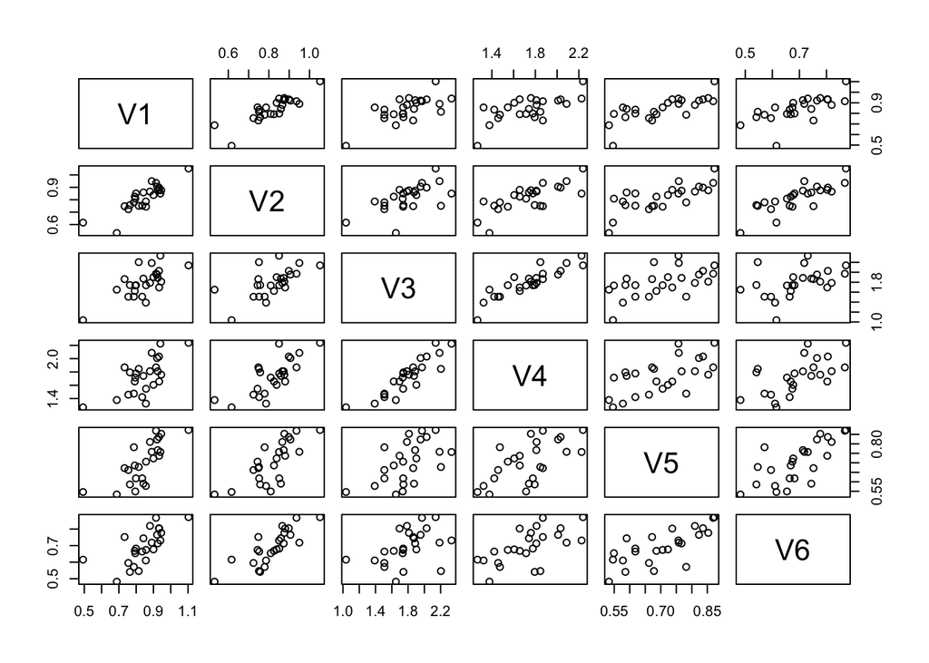

```r
pairs(X1)
```

## 1.18

1.17

We first do some routine calculations.

*We need to modify “KOR, S” to “KOR(S)” and do the similar for “KOR, N” to ensure that the data can be properly imported.*

```r
X2 <- read.table('T1-9.DAT', row.names = 1)
head(X2)
```

```
##       V2   V3   V4   V5   V6   V7  V8
## ARG 11.6 22.9 52.5 2.05 4.25 9.19 150
## AUS 11.1 22.2 48.6 1.98 4.02 8.63 144
## AUT 11.2 22.7 50.6 1.94 4.05 8.78 154
## BEL 11.1 22.5 51.5 1.97 4.08 8.82 143
## BER 11.5 23.1 53.3 2.07 4.29 9.81 174
## BRA 11.2 22.6 50.6 1.97 4.17 9.04 147
```

```r
n2 <- nrow(X2) # sample sizes

avgX2 <- colMeans(X2) # means
avgX2
```

```
##     V2     V3     V4     V5     V6     V7     V8
##  11.36  23.12  51.99   2.02   4.19   9.08 153.62
```

```r
S2 <- cov(X2) # sample covariance, divided by n-1
Sn2 <- S2 * (n2 - 1) / n2 # divided by n
Sn2
```

```
##        V2      V3     V4      V5     V6      V7     V8
## V2 0.1524  0.3382  0.875 0.02719 0.0823  0.2296   4.25
## V3 0.3382  0.8471  2.152 0.06494 0.1990  0.5441  10.19
## V4 0.8748  2.1522  6.621 0.17844 0.4997  1.4004  28.37
## V5 0.0272  0.0649  0.178 0.00741 0.0210  0.0602   1.20
## V6 0.0823  0.1990  0.500 0.02102 0.0728  0.2122   3.47
## V7 0.2296  0.5441  1.400 0.06024 0.2122  0.6524  10.51
## V8 4.2539 10.1927 28.368 1.19707 3.4743 10.5078 265.27
```

```r
cor2 <- cor(X2) # correlation coefs
cor2
```

```
##       V2    V3    V4    V5    V6    V7    V8
## V2 1.000 0.941 0.871 0.809 0.782 0.728 0.669
## V3 0.941 1.000 0.909 0.820 0.801 0.732 0.680
## V4 0.871 0.909 1.000 0.806 0.720 0.674 0.677
## V5 0.809 0.820 0.806 1.000 0.905 0.867 0.854
## V6 0.782 0.801 0.720 0.905 1.000 0.973 0.791
## V7 0.728 0.732 0.674 0.867 0.973 1.000 0.799
## V8 0.669 0.680 0.677 0.854 0.791 0.799 1.000
```

We can see from the first row that the magnitudes of the correlation coefs decrease as we go from shorter (100m) to the longer (marathon) running distances (all regarding to 100m). This means that shorter distance running records are more correlated with shorter ones than longer ones. Similarly, from the last row we interpret that longer distance running records are more correlated with longer ones than shorter ones.

1.18

Now we convert the records into speed measured in meters per second.

```r
scale <- c(100, 200, 400, 800 / 60, 1500 / 60, 3000 / 60, 42195 / 60) # scales
X2_converted <- t(scale / t(X2)) # Element-wise division in R are done in terms of each column; transpose needed
head(X2_converted)
```

```
##       V2   V3   V4   V5   V6   V7   V8
## ARG 8.64 8.72 7.62 6.50 5.88 5.44 4.68
## AUS 8.99 9.00 8.23 6.73 6.22 5.79 4.90
## AUT 8.97 8.81 7.90 6.87 6.17 5.69 4.56
## BEL 8.98 8.90 7.77 6.77 6.13 5.67 4.92
## BER 8.73 8.68 7.50 6.44 5.83 5.10 4.04
## BRA 8.95 8.85 7.90 6.77 6.00 5.53 4.77
```

```r
avgX2_converted <- colMeans(X2_converted) # means
avgX2_converted
```

```
##   V2   V3   V4   V5   V6   V7   V8
## 8.81 8.66 7.71 6.60 5.99 5.54 4.62
```

```r
S2_converted <- cov(X2_converted) # sample covariance, divided by n-1
Sn2_converted <- S2 * (n2 - 1) / n2 # divided by n
Sn2_converted
```

```
##        V2      V3     V4      V5     V6      V7     V8
## V2 0.1524  0.3382  0.875 0.02719 0.0823  0.2296   4.25
## V3 0.3382  0.8471  2.152 0.06494 0.1990  0.5441  10.19
## V4 0.8748  2.1522  6.621 0.17844 0.4997  1.4004  28.37
## V5 0.0272  0.0649  0.178 0.00741 0.0210  0.0602   1.20
## V6 0.0823  0.1990  0.500 0.02102 0.0728  0.2122   3.47
## V7 0.2296  0.5441  1.400 0.06024 0.2122  0.6524  10.51
## V8 4.2539 10.1927 28.368 1.19707 3.4743 10.5078 265.27
```

```r
cor2_converted <- cor(X2_converted) # correlation coefs
cor2_converted
```

```
##       V2    V3    V4    V5    V6    V7    V8
## V2 1.000 0.938 0.866 0.797 0.776 0.729 0.660
## V3 0.938 1.000 0.906 0.816 0.806 0.741 0.675
## V4 0.866 0.906 1.000 0.804 0.731 0.694 0.672
## V5 0.797 0.816 0.804 1.000 0.906 0.875 0.852
## V6 0.776 0.806 0.731 0.906 1.000 0.972 0.824
## V7 0.729 0.741 0.694 0.875 0.972 1.000 0.854
## V8 0.660 0.675 0.672 0.852 0.824 0.854 1.000
```

We can see from the first row that the magnitudes of the correlation coefs decrease as we go from shorter (100m) to the longer (marathon) running distances (all regarding to 100m). This means that shorter distance running record speeds are more correlated with shorter ones than longer ones. Similarly, from the last row we interpret that longer distance running records speeds are more correlated with longer ones than shorter ones. These results agree with those of in Ex 1.17.

## 1.27

Import data

```r
X3 <- read.table('T1-11.DAT', col.names = c("sizes", "visitors"))
head(X3)
```

```
##    sizes visitors
## 1   47.4     2.05
## 2   35.8     1.02
## 3   32.9     2.53
## 4 1508.5     1.23
## 5 1217.4     4.40
## 6  310.0     2.46
```

Compute means, covariance and correlation matrix

```r
n3 <- nrow(X3) # sample sizes

avgX3 <- colMeans(X3) # means
avgX3
```

```
##    sizes visitors
##   562.01     2.74
```

```r
S3 <- cov(X3) # sample covariance, divided by n-1
Sn3 <- S3 * (n3 - 1) / n3 # divided by n
Sn3
```

```
##           sizes visitors
## sizes    395899   213.19
## visitors    213     3.86
```

```r
cor3 <- cor(X3[ ,1], X3[, 2]) # correlation coefs
cor3
```

```
## [1] 0.173
```

Scatter plot

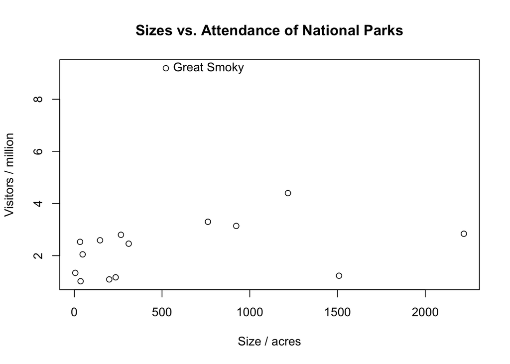

```r
plot(X3[,1], X3[,2], xlab = "Size / acres", ylab = "Visitors / million", main = "Sizes vs. Attendance of National Parks")
ind <- which.max(X3[,2])
text(X3[ind,1], X3[ind,2], labels = "Great Smoky", pos = 4)
```

We can see that there is an unusual point in the upper left (Great Smoky)

```r
cor3_dropped <- cor(X3[-ind, 1], X3[-ind, 2])
cor3_dropped
```

```
## [1] 0.391
```

After dropping this point, the correlation coef changes from .173 to .391. Clearly, this atypical data point significantly reduces the correlation coefficient.

The correlation won’t change if we measure size in square miles because if we do that the size data only differs a constant factor, which is normalized in the correlation coefficient formula (divide by square root of the variance).